# Linear Regression on Advertising Data

Shiva Kumar Pendem

```r
library(ggplot2)
library(car)
library(vctrs)
library(plotly)
```

## Task 1: Load and visualize the data

### Loading the Data and getting summary

```r
advertising_data <- read.csv("Advertising.csv", colClasses = c("NULL", NA,NA,NA,NA))

head(advertising_data)
```

|  | TV | Radio | Newspaper | Sales |
| --- | --- | --- | --- | --- |
| 1 | 230.1 | 37.8 | 69.2 | 22.1 |
| 2 | 44.5 | 39.3 | 45.1 | 10.4 |
| 3 | 17.2 | 45.9 | 69.3 | 9.3 |
| 4 | 151.5 | 41.3 | 58.5 | 18.5 |
| 5 | 180.8 | 10.8 | 58.4 | 12.9 |
| 6 | 8.7 | 48.9 | 75.0 | 7.2 |

```r
summary(advertising_data)
```

```
       TV             Radio          Newspaper          Sales
 Min.   :  0.70   Min.   : 0.000   Min.   :  0.30   Min.   : 1.60
 1st Qu.: 74.38   1st Qu.: 9.975   1st Qu.: 12.75   1st Qu.:10.38
 Median :149.75   Median :22.900   Median : 25.75   Median :12.90
 Mean   :147.04   Mean   :23.264   Mean   : 30.55   Mean   :14.02
 3rd Qu.:218.82   3rd Qu.:36.525   3rd Qu.: 45.10   3rd Qu.:17.40
 Max.   :296.40   Max.   :49.600   Max.   :114.00   Max.   :27.00
```

## Task 2: Simple linear regression

```r
par(mfrow=c(1,3))


plot(advertising_data$TV, advertising_data$Sales, main="TV vs Sales", xlab="TV", ylab="Sales")
plot(advertising_data$Radio, advertising_data$Sales, main="Radio vs Sales", xlab="Radio", ylab="Sales")
```

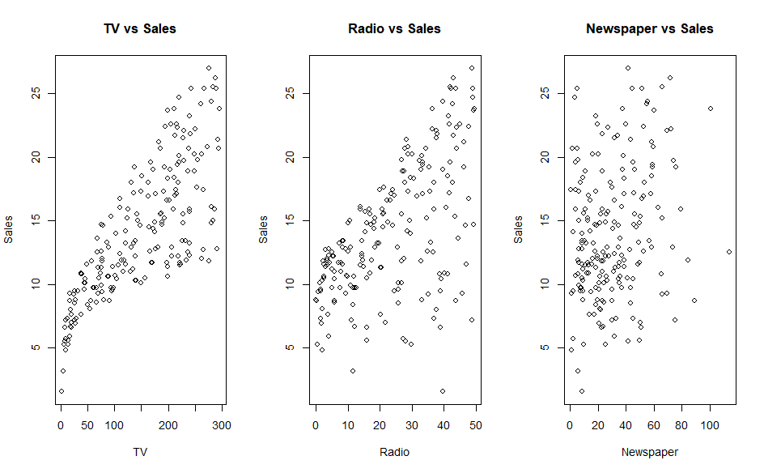

```r
plot(advertising_data$Newspaper, advertising_data$Sales, main="Newspaper vs Sales", xlab="Newspaper", ylab="Sales")


par(mfrow=c(1,1))
```

```r
multi_model <- lm(Sales ~ TV + Radio + Newspaper, data = advertising_data)
summary(multi_model)
```

```
Call:
lm(formula = Sales ~ TV + Radio + Newspaper, data = advertising_data)

Residuals:
    Min      1Q  Median      3Q     Max
-8.8277 -0.8908  0.2418  1.1893  2.8292

Coefficients:
             Estimate Std. Error t value Pr(>|t|)
(Intercept)  2.938889   0.311908   9.422   <2e-16 ***
TV           0.045765   0.001395  32.809   <2e-16 ***
Radio        0.188530   0.008611  21.893   <2e-16 ***
Newspaper   -0.001037   0.005871  -0.177     0.86
---
Signif. codes:  0 ‘***’ 0.001 ‘**’ 0.01 ‘*’ 0.05 ‘.’ 0.1 ‘ ’ 1

Residual standard error: 1.686 on 196 degrees of freedom
Multiple R-squared:  0.8972,    Adjusted R-squared:  0.8956
F-statistic: 570.3 on 3 and 196 DF,  p-value: < 2.2e-16
```

### Plotting with Regression Line

```r
par(mfrow=c(1,3))

# TV vs Sales
plot(advertising_data$TV, advertising_data$Sales, main="TV vs Sales", xlab="TV", ylab="Sales")
model_tv <- lm(Sales ~ TV, data=advertising_data)
abline(model_tv, col="red")
```

```r
# Radio vs Sales
plot(advertising_data$Radio, advertising_data$Sales, main="Radio vs Sales", xlab="Radio", ylab="Sales")
model_radio <- lm(Sales ~ Radio, data=advertising_data)
abline(model_radio, col="red")
```

```r
# Newspaper vs Sales
plot(advertising_data$Newspaper, advertising_data$Sales, main="Newspaper vs Sales", xlab="Newspaper", ylab="Sales")
model_newspaper <- lm(Sales ~ Newspaper, data=advertising_data)
abline(model_newspaper, col="red")
```

[figure not shown]

```r
par(mfrow=c(1,1))
```

### Based on the the results:

The coefficients of TV, Radio and Newspaper are 0.045, 0.188, -0.001 respectively.

TV and Radio contribute to sales because the coeff is significant, which we can’t say for Newspaper.

Based on the t-values:

There’s a strong positive relationship between sales and the advertising budgets for both TV and Radio, as indicated by their large positive t-values. The Newspaper advertising budget doesn’t show a statistically significant relationship with sales, given its t-value close to 0. Thus, while TV and Radio budgets have significant positive relationships with sales, the Newspaper budget doesn’t seem to have a meaningful impact on sales. *** \

## Question 3: Multiple Linear Regression

```r
# install.packages(c("car", "rgl"))

summary(multi_model)
```

```
Call:
lm(formula = Sales ~ TV + Radio + Newspaper, data = advertising_data)

Residuals:
    Min      1Q  Median      3Q     Max
-8.8277 -0.8908  0.2418  1.1893  2.8292

Coefficients:
             Estimate Std. Error t value Pr(>|t|)
(Intercept)  2.938889   0.311908   9.422   <2e-16 ***
TV           0.045765   0.001395  32.809   <2e-16 ***
Radio        0.188530   0.008611  21.893   <2e-16 ***
Newspaper   -0.001037   0.005871  -0.177     0.86
---
Signif. codes:  0 ‘***’ 0.001 ‘**’ 0.01 ‘*’ 0.05 ‘.’ 0.1 ‘ ’ 1

Residual standard error: 1.686 on 196 degrees of freedom
Multiple R-squared:  0.8972,    Adjusted R-squared:  0.8956
F-statistic: 570.3 on 3 and 196 DF,  p-value: < 2.2e-16
```

### Revisiting the results:

Again, Looking at the Coefficients of TV and radio tells us the they contribute more to the sales because of their corresponding slopes is more when compared to Newspaper’s slope.

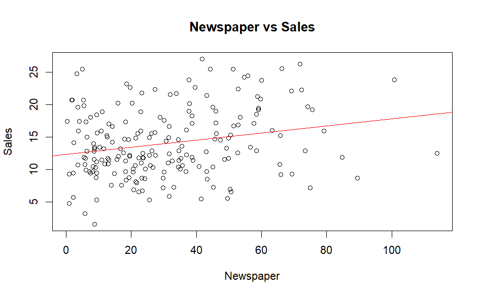

```r
plot(advertising_data$Newspaper, advertising_data$Sales, main="Newspaper vs Sales", xlab="Newspaper", ylab="Sales")
model_newspaper <- lm(Sales ~ Newspaper, data=advertising_data)
abline(model_newspaper, col="red")
```

```r
summary(model_newspaper)
```

```
Call:
lm(formula = Sales ~ Newspaper, data = advertising_data)

Residuals:
     Min       1Q   Median       3Q      Max
-11.2272  -3.3873  -0.8392   3.5059  12.7751

Coefficients:
            Estimate Std. Error t value Pr(>|t|)
(Intercept) 12.35141    0.62142   19.88  < 2e-16 ***
Newspaper    0.05469    0.01658    3.30  0.00115 **
---
Signif. codes:  0 ‘***’ 0.001 ‘**’ 0.01 ‘*’ 0.05 ‘.’ 0.1 ‘ ’ 1

Residual standard error: 5.092 on 198 degrees of freedom
Multiple R-squared:  0.05212,   Adjusted R-squared:  0.04733
F-statistic: 10.89 on 1 and 198 DF,  p-value: 0.001148
```

### Multiple and Simple Regression for Newspaper regressor.

When performing the simple regression on newspaper alone, it gives us the coeff of 0.0546. Indicating a good relationship

But when we do multiple linear regression the slope of newspaper is -0.001037 and the p-value is 0.86. Indicating, that it doesn’t have much affect on sales.

```r
correlation_matrix <- cor(advertising_data[, c('Sales','TV', 'Radio', 'Newspaper')])
print(correlation_matrix)
```

```
              Sales         TV      Radio  Newspaper
Sales     1.0000000 0.78222442 0.57622257 0.22829903
TV        0.7822244 1.00000000 0.05480866 0.05664787
Radio     0.5762226 0.05480866 1.00000000 0.35410375
Newspaper 0.2282990 0.05664787 0.35410375 1.00000000
```

Looking at the correlation between Newspaper and other regressor tells us it has weak correlation.

```r
r2 = summary(multi_model)$r.squared
print(paste("R-squared value is:", r2))
```

```
[1] "R-squared value is: 0.897210638178952"
```

The R-Squared Value is 0.89

```r
scatter3d(Sales ~ TV + Radio, data = advertising_data)
# scatter3d(Sales ~ TV + Newspaper, data = advertising_data)
# scatter3d(Sales ~ Newspaper + Radio, data = advertising_data)
```

## Task 4: Models with interaction terms

```r
synergy_model <- lm(Sales ~ TV + Radio + Newspaper + TV*Radio, data = advertising_data)
summary(synergy_model)
```

```
Call:
lm(formula = Sales ~ TV + Radio + Newspaper + TV * Radio, data = advertising_data)

Residuals:
    Min      1Q  Median      3Q     Max
-6.2929 -0.3983  0.1811  0.5957  1.5009

Coefficients:
             Estimate Std. Error t value Pr(>|t|)
(Intercept) 6.728e+00  2.533e-01  26.561  < 2e-16 ***
TV          1.907e-02  1.509e-03  12.633  < 2e-16 ***
Radio       2.799e-02  9.141e-03   3.062  0.00251 **
Newspaper   1.444e-03  3.295e-03   0.438  0.66169
TV:Radio    1.087e-03  5.256e-05  20.686  < 2e-16 ***
---
Signif. codes:  0 ‘***’ 0.001 ‘**’ 0.01 ‘*’ 0.05 ‘.’ 0.1 ‘ ’ 1

Residual standard error: 0.9455 on 195 degrees of freedom
Multiple R-squared:  0.9678,    Adjusted R-squared:  0.9672
F-statistic:  1466 on 4 and 195 DF,  p-value: < 2.2e-16
```

### Synergy between TV & Radio:

After including the TV x Radio term in the multi-linear regression. It gives the coefficient of TV:Radio to be 0.001087, although the slope in minimum, the relationship of TV:Radio can’t be ignored because the corresponding significance code is *** and the p-value is less and almost as TV’s p-value.

```r
#testing all possible variations of  interactions
testing_model <- lm(Sales ~ TV + Radio + Newspaper + TV*Radio + Radio*Newspaper + Newspaper*TV, data = advertising_data)
summary(testing_model)
```

```
Call:
lm(formula = Sales ~ TV + Radio + Newspaper + TV * Radio + Radio *
    Newspaper + Newspaper * TV, data = advertising_data)

Residuals:
    Min      1Q  Median      3Q     Max
-5.9239 -0.3954  0.1873  0.5976  1.5267

Coefficients:
                  Estimate Std. Error t value Pr(>|t|)
(Intercept)      6.460e+00  3.176e-01  20.342   <2e-16 ***
TV               2.033e-02  1.609e-03  12.633   <2e-16 ***
Radio            2.293e-02  1.141e-02   2.009   0.0460 *
Newspaper        1.703e-02  1.007e-02   1.691   0.0924 .
TV:Radio         1.139e-03  5.716e-05  19.930   <2e-16 ***
Radio:Newspaper -1.096e-04  2.363e-04  -0.464   0.6433
TV:Newspaper    -7.971e-05  3.579e-05  -2.227   0.0271 *
---
Signif. codes:  0 ‘***’ 0.001 ‘**’ 0.01 ‘*’ 0.05 ‘.’ 0.1 ‘ ’ 1

Residual standard error: 0.9383 on 193 degrees of freedom
Multiple R-squared:  0.9686,    Adjusted R-squared:  0.9677
F-statistic: 993.3 on 6 and 193 DF,  p-value: < 2.2e-16
```

### Task 5: Optimize Sales

```r
finalmodel <- lm(Sales ~ TV + Radio  + TV*Radio , data = advertising_data)
summary(finalmodel)
```

```
Call:
lm(formula = Sales ~ TV + Radio + TV * Radio, data = advertising_data)

Residuals:
    Min      1Q  Median      3Q     Max
-6.3366 -0.4028  0.1831  0.5948  1.5246

Coefficients:
             Estimate Std. Error t value Pr(>|t|)
(Intercept) 6.750e+00  2.479e-01  27.233   <2e-16 ***
TV          1.910e-02  1.504e-03  12.699   <2e-16 ***
Radio       2.886e-02  8.905e-03   3.241   0.0014 **
TV:Radio    1.086e-03  5.242e-05  20.727   <2e-16 ***
---
Signif. codes:  0 ‘***’ 0.001 ‘**’ 0.01 ‘*’ 0.05 ‘.’ 0.1 ‘ ’ 1

Residual standard error: 0.9435 on 196 degrees of freedom
Multiple R-squared:  0.9678,    Adjusted R-squared:  0.9673
F-statistic:  1963 on 3 and 196 DF,  p-value: < 2.2e-16
```

```r
max(advertising_data$Sales)
```

```
[1] 27
```

```r
print(paste('The maximum sales of existing data is', max(advertising_data$Sales), 'units'))
```

```
[1] "The maximum sales of existing data is 27 units"
```

```r
confint(finalmodel, 'TV', level=0.95)
```

```
        2.5 %     97.5 %
TV 0.01613469 0.02206746
```

```r
confint(finalmodel, 'Radio', level=0.95)
```

```
           2.5 %    97.5 %
Radio 0.01129788 0.0464228
```

Above is the calculation for Confidence interval for TV and Radio features.

```r
predict(finalmodel, data.frame('TV'=145.534, 'Radio' = 154.465))
```

```
       1
38.41229
```